# iDEP: Identifying Differentially Expressed Genes

## If this site has contributed to your work, please cite our article:

Ge, S.X., Son, E.W. & Yao, R. iDEP: an integrated web application for differential expression and pathway analysis of RNA-Seq data. BMC Bioinformatics 19, 534 (2018). https://doi.org/10.1186/s12859-018-2486-6

## Summary

Normalized expression values were analyzed using iDEP v2.5.0. The data was first filtered to remove genes below -1000 in at least 1 sample. The data was not log transformed. Missing values were imputed using geneMedian.

After mapping, there are 16611 unique genes in 24 samples. Of the 16611 genes passed filter, 16077 were converted to Ensembl/STRING gene IDs in our database. The remaining 534 genes were kept in the data using original IDs.

Differential expression analysis was performed using limma with an FDR cutoff of 0.05 and a minimum fold-change threshold of 2.

## DEG Analysis Results

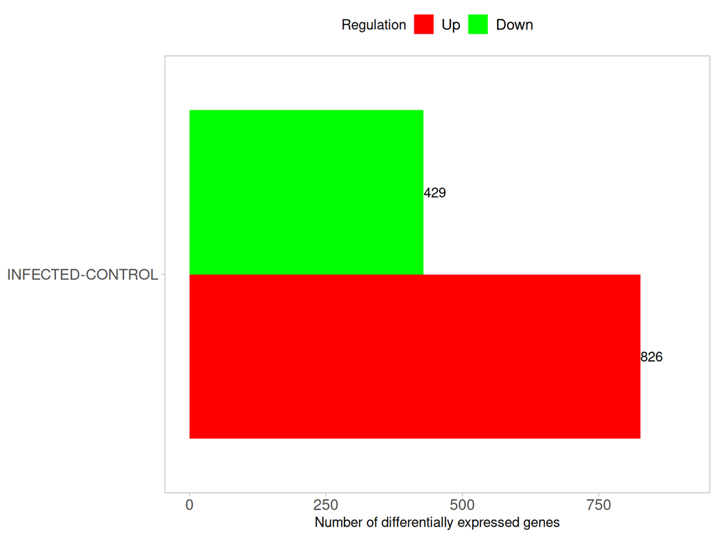

```r
if (!is.null(params$deg_results)) {
  p <- sig_genes_plot(
    results = params$deg_results,
    plot_colors = params$plot_colors
  )
  p <- refine_ggplot2(
    p = p,
    gridline = params$plot_grid_lines,
    ggplot2_theme = params$ggplot2_theme
  )
  print(p)
}
```

## DEG Summary Table

```r
if (!is.null(params$stats_table)) {
  knitr::kable(
    params$stats_table,
    caption = "Numbers of differentially expressed genes for all comparisons",
    row.names = FALSE
  )
}
```

Numbers of differentially expressed genes for all comparisons

| Comparison | Up | Down |
| --- | --- | --- |
| INFECTED-CONTROL | 826 | 429 |

```r
cat("\n<br>\n\n## Venn Diagram\n\n")
if (!is.null(params$venn_comparisons)) {
  cat("Comparing", length(params$venn_comparisons), "selected comparison(s)")
  if (params$up_down_regulated) {
    cat(", with up- and down-regulated genes separated.\n\n")
  } else {
    cat(".\n\n")
  }
}
```

[output not shown]

```r
if (!is.null(params$venn_data)) {
  venn_plot <- plot_venn(
    results = params$venn_data,
    plots_color_select = params$plots_color_select
  )
  # plot_venn uses base graphics, so no need for print()
}
```

```r
cat("\n<br>\n\n### UpSet Plot\n\n")
cat("The UpSet plot is an alternative to the Venn diagram, showing the intersections of the data in the combination matrix (bottom). The columns show how many genes are in each intersection.\n\n")
```

[output not shown]

```r
if (!is.null(params$venn_data)) {
  p <- plot_upset(results = params$venn_data)
  p <- refine_ggplot2(
    p = p,
    gridline = params$plot_grid_lines,
    ggplot2_theme = params$ggplot2_theme
  )
  print(p)
}
```

```r
cat("\n<br>\n\n## R Code\n\n")
```

## R Code

```r
cat("The following R code can be used to redo the differential expression analysis:\n\n")
```

The following R code can be used to redo the differential expression analysis:

````r
if (!is.null(params$r_code)) {
  cat("```r\n")
  cat(params$r_code)
  cat("\n```\n")
}
````

````
```r
# R script for differential expression using the limma package
# generated by iDEP on Sun Sep 27 13:16:58 2026
# Please cite https://doi.org/10.1186/s12859-018-2486-6

# R version 4.5.1 (2025-06-13)
if (!require("BiocManager", quietly = TRUE))
  install.packages("BiocManager")  # v. 1.30.26
if (!require("limma", quietly = TRUE))
  BiocManager::install("limma")  # v. 3.64.3
if (!require("edgeR", quietly = TRUE))
  BiocManager::install("edgeR")  # v. 4.6.3
if (!require("Biobase", quietly = TRUE))
  BiocManager::install("Biobase")  # v. 2.68.0
library(limma) # D.E.G.
library(edgeR) # Data transformation
library(Biobase) # ExpressionSet object
FC <- 2 # Fold-change cutoff
FDR <- 0.05 # FDR cutoff
limma_trend <- FALSE

# Prepare data--------------------------------
# Use normalized data downloaded by clicking the "Processed Data"
# on the Pre-Process tab.
df = read.csv("processed_data.csv")
row.names(df) <- df$User_ID
df <- df[, -(1:3)] # delete 3 columns of IDs
str(df)
eset <- methods::new("ExpressionSet", exprs = as.matrix(df))
sample_info <- data.frame(
  "Treatment" = c("CONTROL", "CONTROL", "CONTROL", "CONTROL", "CONTROL", "CONTROL", "CONTROL", "CONTROL", "CONTROL", "CONTROL", "CONTROL", "CONTROL", "INFECTED", "INFECTED", "INFECTED", "INFECTED", "INFECTED", "INFECTED", "INFECTED", "INFECTED", "INFECTED", "INFECTED", "INFECTED", "INFECTED")
)
model_factors <- c("Treatment")
key_model_factors <- c("Treatment")
sample_info_filter <- sample_info[, key_model_factors, drop = F]
groups <- c("CONTROL", "CONTROL", "CONTROL", "CONTROL", "CONTROL", "CONTROL", "CONTROL", "CONTROL", "CONTROL", "CONTROL", "CONTROL", "CONTROL", "INFECTED", "INFECTED", "INFECTED", "INFECTED", "INFECTED", "INFECTED", "INFECTED", "INFECTED", "INFECTED", "INFECTED", "INFECTED", "INFECTED")
unique_groups <- unique(groups)

# Build model----------------------------
groups <- factor(groups, levels = unique_groups)
````

[output cut: 14 more lines]

````
  fit_contrast,
  p.value = FDR,
  lfc = log2(FC)
)
summary(results)
head(results)
plotMDS(eset) # MDS plot of original data

# Comparison: 1 of 1:INFECTED-CONTROL
stats <- limma::topTable(fit_contrast, coef = 1, number = Inf, sort.by = "log2FC")
table(sign(subset(stats, adj.P.Val < FDR & abs(log2FC) > log2(FC))$log2FC))
plotMD(fit_contrast, coef = 1, status = results)
volcanoplot(fit_contrast, coef = 1, names = row.names(eset), highlight = 10)

```
````

Generated using iDEP v2.5.0 (https://bioinformatics.sdstate.edu/idep). 2026-09-27 13:23:33 UTC. Accuracy not guaranteed.